# NLSY79 longitudinal project

## Mean Income by Broad Hair Color Categories

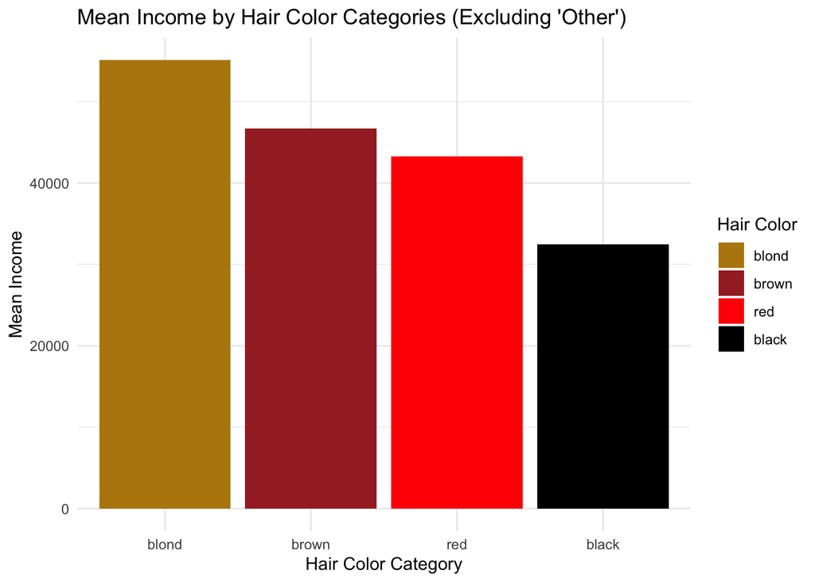

```r
#the other category looks misleading so we should filter this out
# Calculate the mean income for each broad hair color category, excluding "other"
mean_income_by_color_exclude_other <- data %>%
  filter(broad_hair_color != "other") %>%
  group_by(broad_hair_color) %>%
  summarize(mean_income = mean(income, na.rm = TRUE))

# Reorder the broad hair color categories by mean income in descending order
mean_income_by_color_exclude_other <- mean_income_by_color_exclude_other %>%
  mutate(broad_hair_color = reorder(broad_hair_color, -mean_income))

# Create a bar plot for mean income by broad hair color with custom colors
p <- ggplot(mean_income_by_color_exclude_other, aes(x = broad_hair_color, y = mean_income, fill = broad_hair_color)) +
  geom_bar(stat = "identity") +
  labs(title = "Mean Income by Hair Color Categories (Excluding 'Other')", x = "Hair Color Category", y = "Mean Income") +
  scale_fill_manual(values = hair_color_colors) +  # Use custom colors
 theme_minimal() + labs(fill = "Hair Color")  # Rename the legend

ggsave("mean_income_by_color_exclude_other.png", plot = p)
p
```

```r
# Find the median income for the black hair color
reference_median <- mean_income_by_color_exclude_other %>%
  filter(broad_hair_color == "black") %>%
  pull(mean_income)

# Calculate the percentage difference compared to black category
mean_income_by_color_exclude_other <- mean_income_by_color_exclude_other %>%
  mutate(percentage_difference = ((mean_income - reference_median) / reference_median) * 100) %>%

# Sort the data in ascending order of percentage difference
  arrange(percentage_difference)

mean_income_by_color_exclude_other
```

| broad_hair_color | mean_income | percentage_difference |
| --- | --- | --- |
| black | 32471.66 | 0.00000 |
| red | 43301.60 | 33.35195 |
| brown | 46683.38 | 43.76650 |
| blond | 55116.43 | 69.73700 |

To compensate for this, we grouped our hair colors into broader categories, such as combining different shades of blond and brown while preserving other types as they were. We acknowledge the small count in the “other” category. We will make further adjustments, setting the stage for further analysis of income across these newly defined hair color groups.

To begin analyzing this information, we calculate the average income for the different hair color categories we are looking at. We create a bar plot to visualize the mean income. As we mentioned earlier, the “other” category was included in our dataset, and when it is graphed, it appears misleading. We created a new plot and excluded the “other” classification. We recalculated the mean income for the remaining colors. Based on the information in our dataset, we saw that people with blond hair, on average, have a higher mean income than those with black, brown, or red hair.

## Combined Effects of Education and Hair on Income

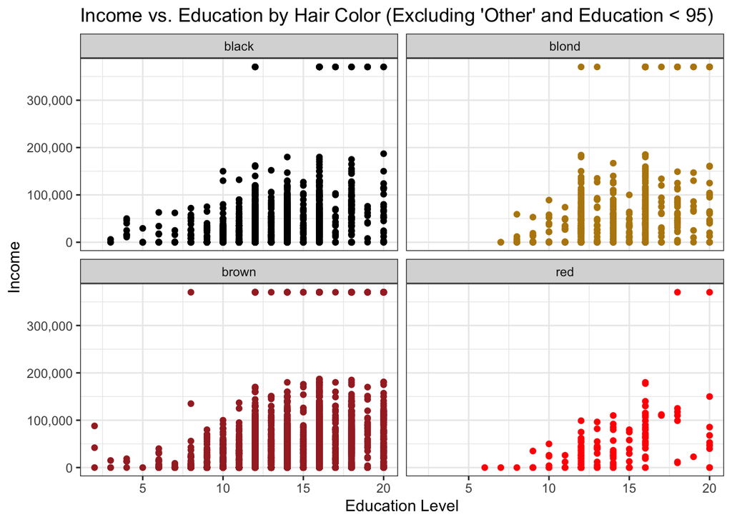

```r
# Create a faceted scatterplot of income vs. education
p <- ggplot(data %>% filter(broad_hair_color != "other",  !is.na(income)),
       aes(x = education, y = income)) +
  geom_point(aes(color = broad_hair_color)) +
  facet_wrap(~broad_hair_color) +
  labs(x = "Education Level", y = "Income", title = "Income vs. Education by Hair Color (Excluding 'Other' and Education < 95)") +
  scale_color_manual(values = hair_color_colors) +
  theme_bw() +
  guides(color = "none") +  # Remove the color legend
  scale_y_continuous(labels = scales::comma)

ggsave("Income_vs_Education_by_HairColor.png", plot = p)
p
```

## Combined Effects of Gender and Hair on Income

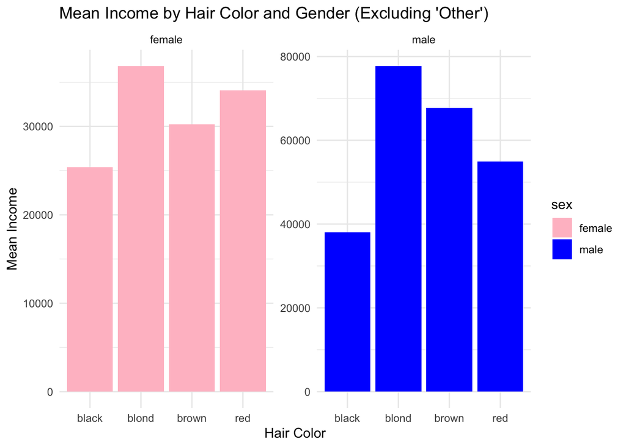

```r
# Filter the data to exclude "other"
filtered_data <- data %>%
  filter(broad_hair_color != "other")

# Group the filtered data by broad_hair_color and gender, and calculate mean income
income_by_color_gender <- filtered_data %>%
  group_by(broad_hair_color, sex) %>%
  summarize(mean_income = mean(income, na.rm = TRUE))
# Define custom colors for gender
sex_color <- c(
  "male" = "blue",
  "female" = "pink"
)

# Create a faceted bar plot for mean income by hair color and gender
p <- ggplot(income_by_color_gender, aes(x = broad_hair_color, y = mean_income, fill = sex)) +
  geom_bar(stat = "identity", position = "dodge") +
  labs(x = "Hair Color", y = "Mean Income", title = "Mean Income by Hair Color and Gender (Excluding 'Other')") +
  scale_fill_manual(values = sex_color) +  # Custom colors
  theme_minimal() +
  facet_wrap(~sex, scales = "free_y")  # Facet by gender with independent y-axes
ggsave("income_by_color_gender.png", plot = p)
p
```

```r
# Group the data by broad_hair_color, sex, and calculate mean income
mean_income_by_color_gender <- data %>%
  group_by(broad_hair_color, sex) %>%
  summarize(mean_income = mean(income, na.rm = TRUE))
# Check the summary
mean_income_by_color_gender
```

| broad_hair_color | sex | mean_income |
| --- | --- | --- |
| black | female | 25402.55 |
| black | male | 38064.69 |
| blond | female | 36829.21 |
| blond | male | 77714.70 |
| brown | female | 30226.17 |
| brown | male | 67718.90 |
| other | male | 55500.00 |
| red | female | 34074.34 |
| red | male | 54935.96 |

```r
# Calculate the mean income for each combination of broad_hair_color and sex
mean_income_by_color_gender <- data %>%
  group_by(broad_hair_color, sex) %>%
  summarize(mean_income = mean(income, na.rm = TRUE))
# Calculate the percentage difference
percentage_difference <- mean_income_by_color_gender %>%
  pivot_wider(names_from = sex, values_from = mean_income) %>%
  mutate(percentage_difference = ((male - female) / female) * 100)

# View the resulting data frame
percentage_difference
```

| broad_hair_color | female | male | percentage_difference |
| --- | --- | --- | --- |
| black | 25402.55 | 38064.69 | 49.84595 |
| blond | 36829.21 | 77714.70 | 111.01377 |
| brown | 30226.17 | 67718.90 | 124.04063 |
| other | NA | 55500.00 | NA |
| red | 34074.34 | 54935.96 | 61.22381 |

We created a faceted plot by filtering the hair color data to exclude the “other” category in the dataset. We then grouped the variables “broad_hair_color” and “sex” to calculate the mean income for each resulting group. Upon reviewing the graph, it is evident that there are gender-based income disparities. In most hair color categories, males tend to have higher mean incomes than females. To provide a more detailed understanding, we present the calculations in terms of percentage variations in the subsequent tables, illustrating these differences.

## Grouped Analysis of Summary Statistics

### Mean and Median Income by Gender

```r
data %>%
  group_by(sex) %>% summarise(Mean=mean(income, na.rm=T),
                              Median=median(income, na.rm=T))
```

| sex | Mean | Median |
| --- | --- | --- |
| female | 29583.82 | 21310 |
| male | 56745.00 | 40000 |

Males seem to have higher average and median income compared with females.

### Mean and Median Income by Hair

```r
data %>%
  group_by(hair) %>% summarise(Mean=mean(income, na.rm=T),
                              Median=median(income, na.rm=T))
```

| hair | Mean | Median |
| --- | --- | --- |
| black | 32471.66 | 21000 |
| blond | 54444.28 | 36000 |
| brown | 46643.14 | 31000 |
| grey | 55500.00 | 55500 |
| light blond | 62044.69 | 34500 |
| light brown | 46848.35 | 33000 |
| red | 43301.60 | 28000 |

### Mean and Median Income by Hair and Gender

```r
data %>%
  group_by(sex, hair) %>% summarise(Mean=mean(income, na.rm=T),
                              Median=median(income, na.rm=T))
```

[output not shown]

| sex | hair | Mean | Median |
| --- | --- | --- | --- |
| female | black | 25402.55 | 18000 |
| female | blond | 37290.65 | 23000 |
| female | brown | 29726.75 | 22000 |
| female | light blond | 32291.67 | 13000 |
| female | light brown | 32042.25 | 23194 |
| female | red | 34074.34 | 22800 |
| male | black | 38064.69 | 25000 |
| male | blond | 75441.46 | 52000 |
| male | brown | 67101.35 | 47000 |
| male | grey | 55500.00 | 55500 |

[output cut: 3 more lines]

```r
data %>%
  group_by(sex) %>% summarise(Proportion=mean(income>200000, na.rm=T))
```

| sex | Proportion |
| --- | --- |
| female | 0.002630041 |
| male | 0.041825095 |

The proportion of income over $200,000 is higher for males than females.

### Proportion With Income More Than 200000 by Hair Color

```r
data %>%
  group_by(hair) %>% summarise(Proportion=mean(income>200000, na.rm=T))
```

| hair | Proportion |
| --- | --- |
| black | 0.01001821 |
| blond | 0.03544776 |
| brown | 0.02702703 |
| grey | 0.00000000 |
| light blond | 0.05769231 |
| light brown | 0.02244039 |
| red | 0.01282051 |

The respondent with light blond color has the highest proportion of income, more than $200,000.

## Hypotheses for Further Analysis

### Hypothesis 1: Education and Income

We hypothesize that there is a positive relationship between education level and income. In our analysis, we saw that individuals with higher levels of education tended to have higher incomes. We expect that as years of education increase, so does the average income.

### Hypothesis 2: Hair Color and Income

Based on our analysis of hair color and income, we hypothesize that certain hair colors may be associated with higher incomes when compared to others. Specifically, our data suggests that individuals with blond hair tend to have a higher mean and median income than those with black, brown, or red hair. This hypothesis may require further investigation to test its statistical significance.